**General Comments [Gallagher’s comments in magenta]:** Your R code, graphics and Tables were phenomenal. You must write concise statements summarizing those tabular and graphical displays. My Ph.D. advisor published in Scientific American, and they told him that their articles had two parallel but strongly interacting components: the graphs & tables and text. Each is essential to convey the story to the reader. In several of your answers, you presented mainly or only the graphical and tabular displays. I’d have you present your work on Tuesday, but you’ve already presented, and I need to assign new students as presenters. **Score: Basic = (5+5)/10; Supplemental = (2.3+2.4)/5; Total points. 14.7/10**

# Question 2.22: Male vs Female Intelligence

First load in and name the data.

```
##   Gender Arith Word Parag Math AFQT
## 1   male    19   27    14   14 70.3
## 2 female    23   34    11   20 60.4
## 3   male    30   35    14   25 98.3
## 4 female    30   35    13   21 84.7
## 5 female    13   30    11   12 44.5
## 6 female     8   15     6    4  4.0
```

Lets take a look at a box plot:

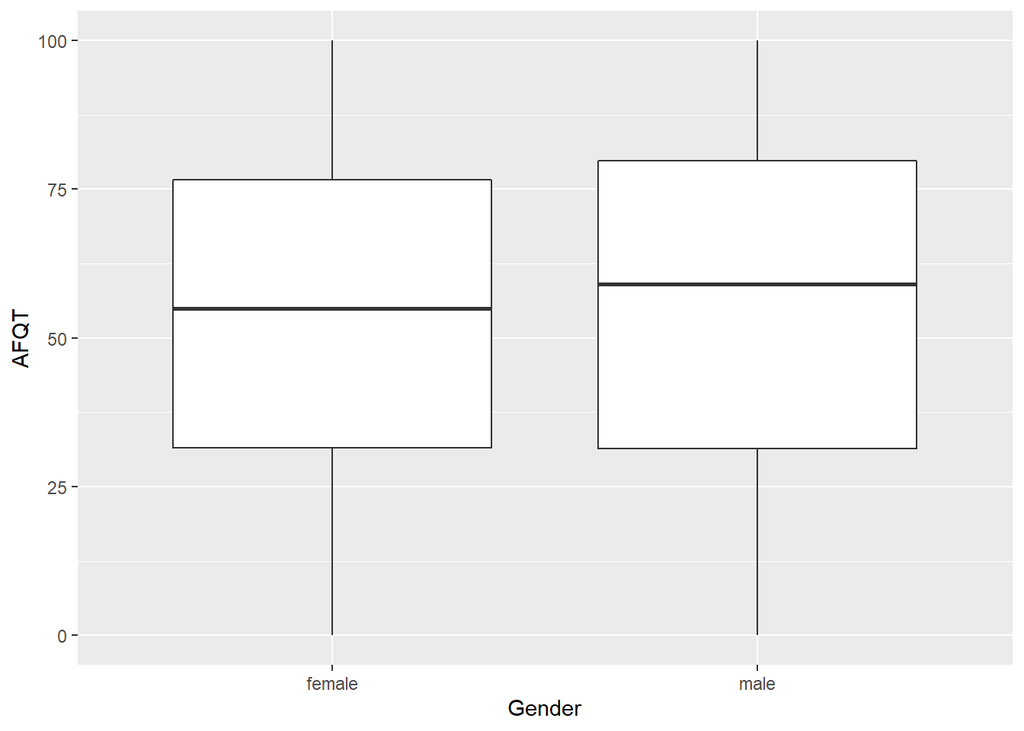

The way the data is formatted right now, it’s hard to plot all the different scores together. So I’m going to reformat using pivot_longer to create one column with all the scores, and then replot the boxplots.

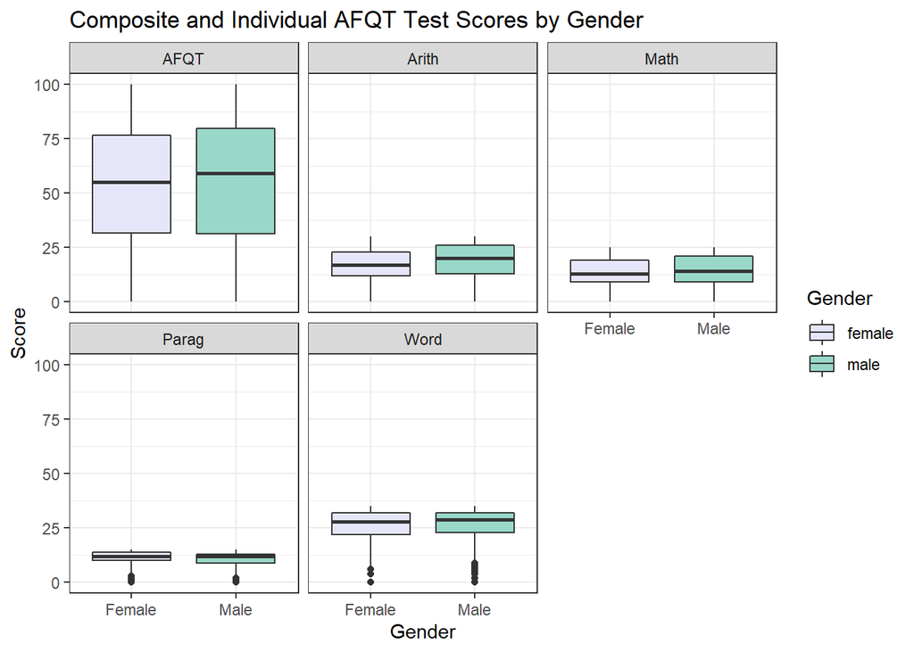

Now I want to perform my t-tests and show them in a table.

[output not shown]

Statistical Summary

[output not shown]

**Comments on Basic Question 2.22:** The graphics and Tables are outstanding. I’ll give a bonus point for those but then take off a point. In addition to the Tables and Graphs, you must summarize in a paragraph those results. In concise sentences, you need to describe the designs (a probability-based random sample of the Nation’s youth), the tests (Student’s *t* tests, the p values, effect sizes, a measure of precision (usually the confidence limits) and your statistical inference. Does this study provide evidence that men are smarter than women, especially in math? The AFQT was treated by Herrenstein & Murray in their controversial book “The Bell Curve” as an IQ test, and they used the scores analyzed by binary logistic regression (Sleuth Ch 20) to justify their belief in a racial difference in IQ, more than can be accounted for by socioeconomic status of the families. The UC Berkeley Sociology Dept wrote a devastating critique of the Bell Curve methods and conclusions and reanalyzed all of the NLSY AFQT data. It is the best of many books published about ‘The Bell Curve.’ I’ll cover more of the story when we reach Ch 20. I don’t have my many Bell Curve books at my home office. **Score = 5/5.**

# Question 3.32: College Tuition

Load in and name the data

```
##                                College    Type InState OutOfState
## 1              Albany State University  Public    5434      17048
## 2         Appalachian State University  Public    5175      16487
## 3         Argosy University: Nashville Private   19596      19596
## 4                   Brescia University Private   18140      18140
## 5 Central Connecticut State University  Public    8055      18679
## 6       Christopher Newport University  Public   10084      19306
```

I want to make sure that I can plot things easily, so I’ll pivot the data to one column.

Now, take a look at the spread of the data

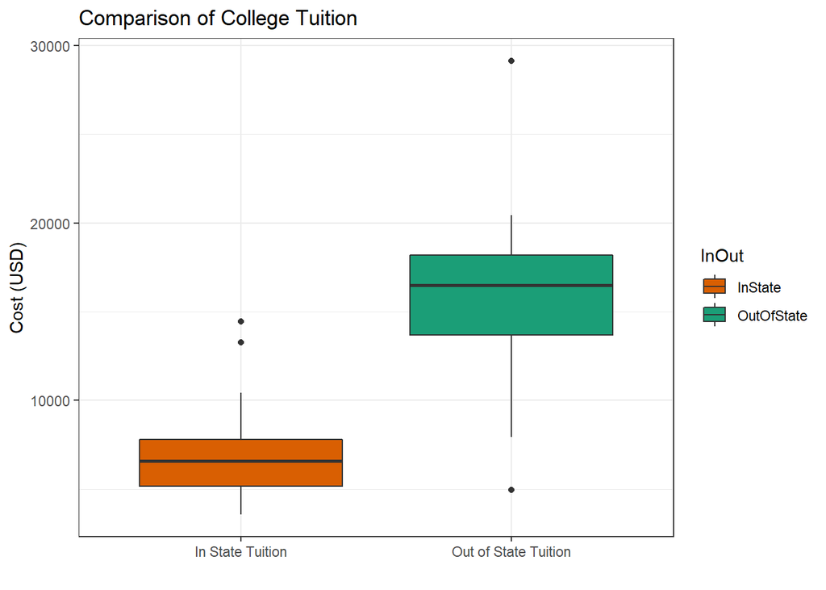

The boxplot shows that the interquartile ranges are quite different. However, I had a hard time visualizing this so I plotted it as a histogram as well to look at the spread.

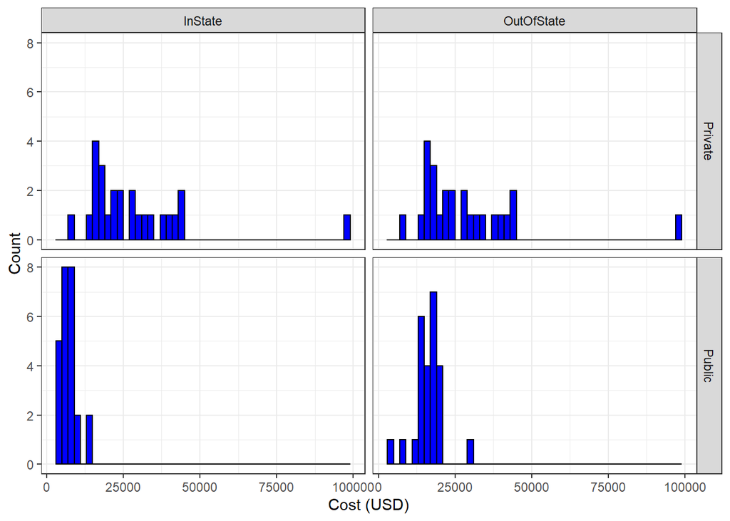

Data are clearly not normal, so we need to do a transformation.

I’ll use BoxCox to see what kind of transformation I need to do.

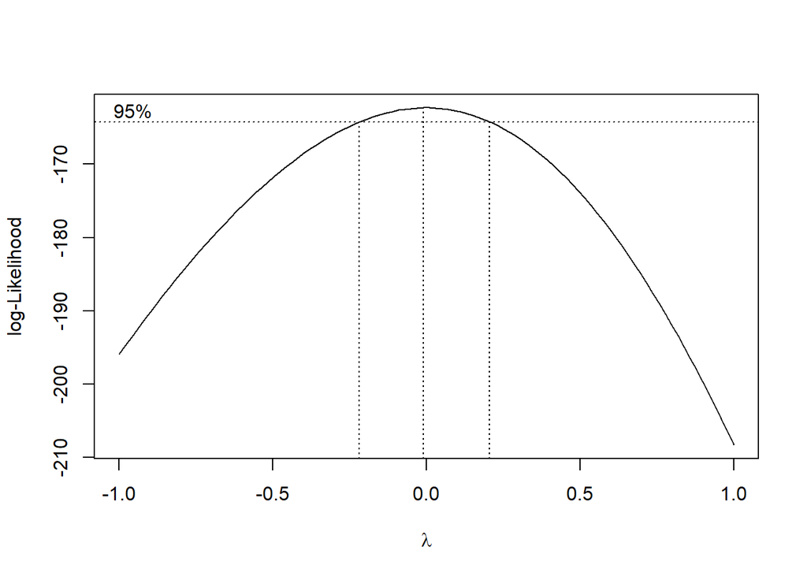

It looks like a log transformation would be appropriate, because lambda is zero.

Now I’ll make box plots for the three comparisons the question asks for. I’m using cowplot to plot them together.

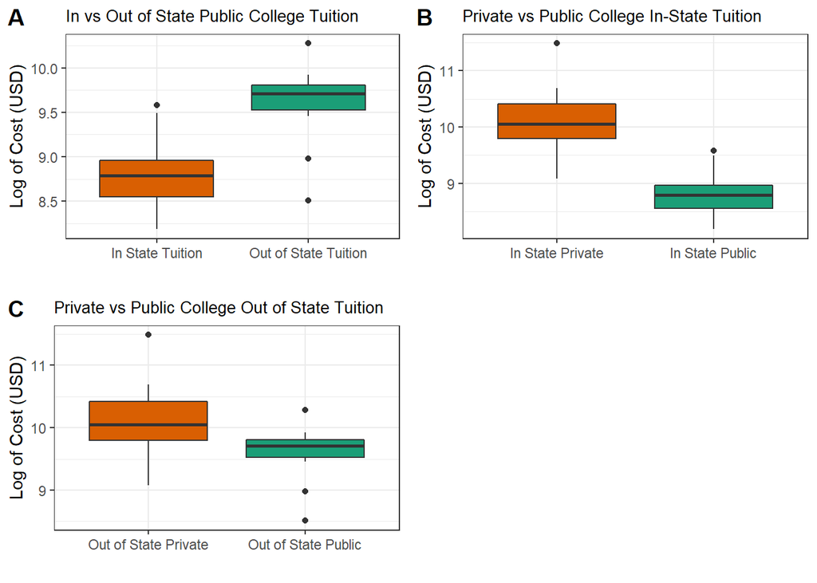

Now we want to look at the statistical summary for these three comparisons.

Statistical Summary

[output not shown]

The results show that there is strong evidence that out of state public school tuition is higher than in state public school tuition, and that private school tuition is higher than public school tuition when looking at either in or out of state costs.

**Basic Problem 3.32 College Tuitions** Your answer is great, but you still should summarize the Tables with text. What were the p values, effect sizes, and confidence intervals? What statistical inference is possible with the sampling design? **Score 5/5**

# Question 2.21 from Sleuth 2: Weights of Birds that Survived and Perished

Read in and check data.

```
##   Weight   Status
## 1   24.5 survived
## 2   26.9 survived
## 3   26.9 survived
## 4   24.3 survived
## 5   24.1 survived
## 6   26.5 survived
```

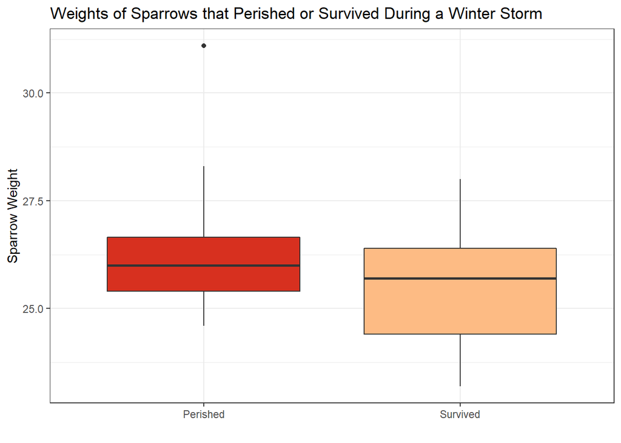

Statistical Summary

| Status | min | Q1 | median | Q3 | max | mean | sd | n | missing |
| --- | --- | --- | --- | --- | --- | --- | --- | --- | --- |
| perished | 24.6 | 25.4 | 26.0 | 26.65 | 31.1 | 26.27500 | 1.472428 | 24 | 0 |
| survived | 23.2 | 24.4 | 25.7 | 26.40 | 28.0 | 25.46286 | 1.258871 | 35 | 0 |

Statistical Summary

| mean in group perished | 26.2750000 |
| --- | --- |
| mean in group survived | 25.4628573 |
| ci.lower | 0.0701121 |
| ci.upper | 1.5541734 |
| p.value | 0.0326621 |

**Supplemental Problem 2.21 Bumpus Sparrows** As in the previous problems, you didn’t write an analysis based on your wonderful tables and graphs. Use the Sleuth summaries at the end of the case studies as a paradigm. They always report the effect size, the test, the p value, and a measure of the error of the estimate, usually the 95% CI. They then make a statistical inference about the data. In this supplemental problem, Bumpus used the sparrow data as evidence for Darwinian selection. Do the data support this conclusion? **Score 2.3/2.5**

# Question 3.31 from Sleuth 2: Iron Supplementation

Load in and check the data

```
##   Iron Supplement
## 1 0.71        Fe3
## 2 1.66        Fe3
## 3 2.01        Fe3
## 4 2.16        Fe3
## 5 2.42        Fe3
## 6 2.42        Fe3
```

Check the spread to see if we need to transform

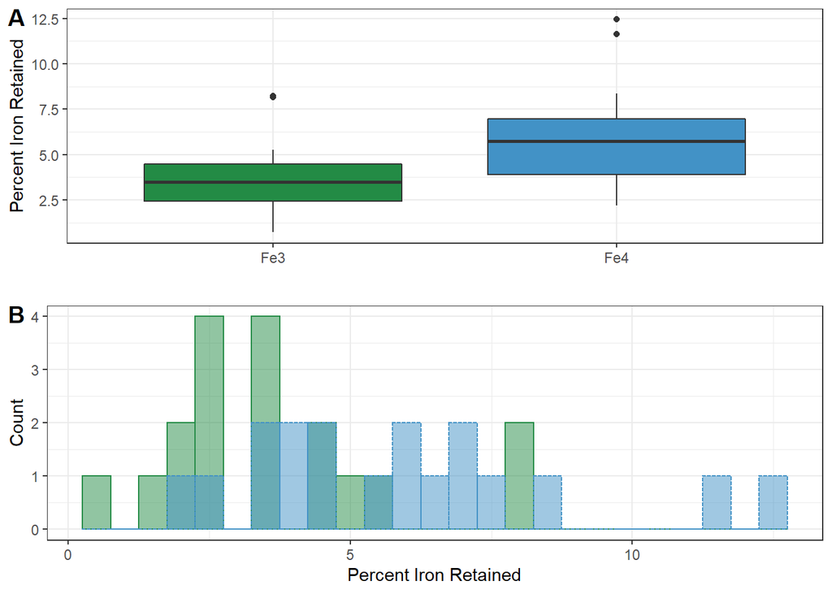

There are some outliers here that maybe we should get rid of.

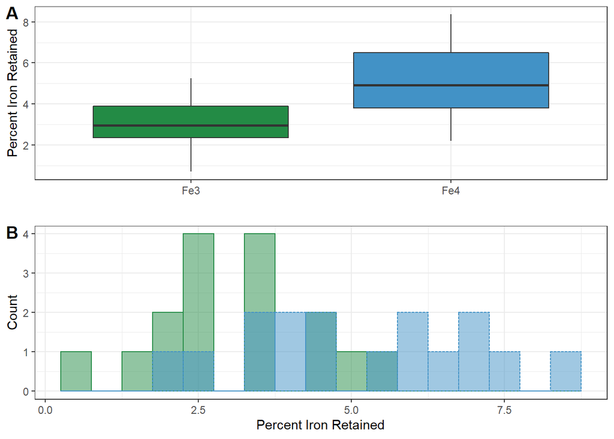

This looks better, but I still think we need a transformation. I’ll use BoxCox to see what type of transformation is warranted.

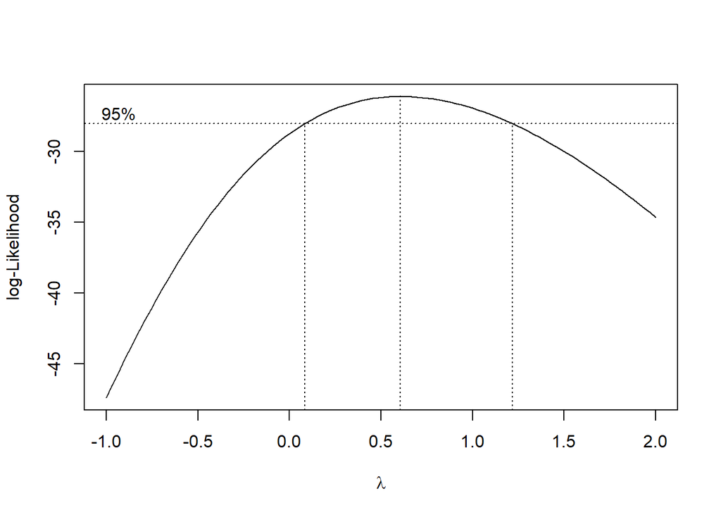

Looks like a square root transformation is suggested (lambda is roughly 0.5). Now we’ll view the data again, do our T test, and report the statistical summary. ..

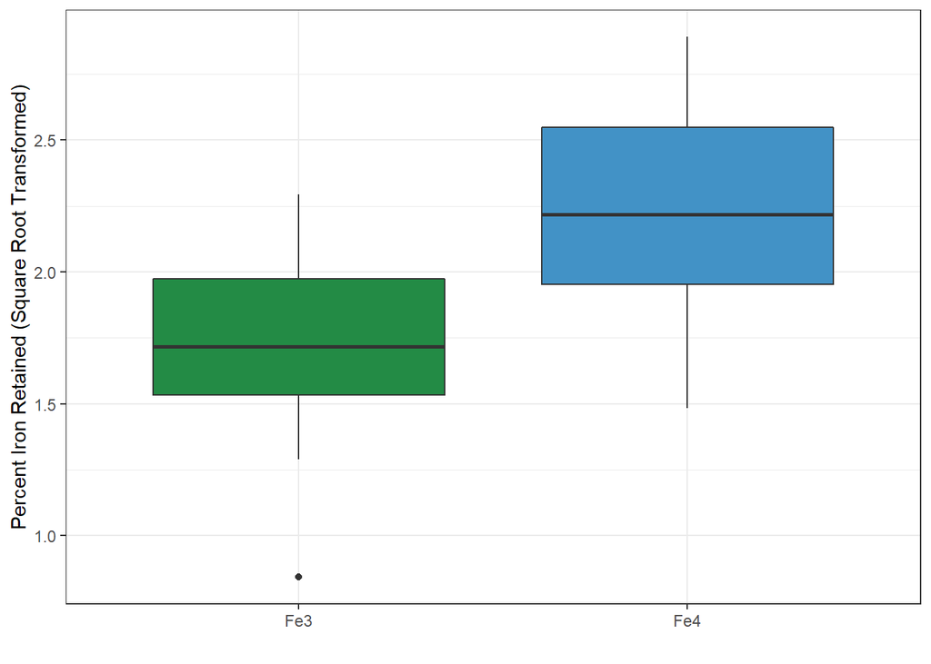

```
##
##  Welch Two Sample t-test
##
## data:  sqrt(Iron) by Supplement
## t = -3.6064, df = 29.891, p-value = 0.001116
## alternative hypothesis: true difference in means between group Fe3 and group Fe4 is not equal to 0
## 95 percent confidence interval:
##  -0.7959476 -0.2203457
## sample estimates:
## mean in group Fe3 mean in group Fe4
##          1.731182          2.239328
```

Statistical Summary

| Supplement | min | Q1 | median | Q3 | max | mean | sd | n | missing |
| --- | --- | --- | --- | --- | --- | --- | --- | --- | --- |
| Fe3 | 0.842615 | 1.534150 | 1.715896 | 1.974239 | 2.293469 | 1.731182 | 0.3862777 | 16 | 0 |
| Fe4 | 1.483240 | 1.951902 | 2.217446 | 2.546981 | 2.891366 | 2.239328 | 0.4104091 | 16 | 0 |

Statistical Summary

| mean in group Fe3 | 1.7311817 |
| --- | --- |
| mean in group Fe4 | 2.2393284 |
| ci.lower | -0.7959476 |
| ci.upper | -0.2203457 |
| p.value | 0.0011160 |

**Supplemental Problem 3.31 Fe(III) & Fe(IV)** In the previous problems, a statistically literate reader could see the story in the tables without a text summary. In this study, a text description of the problem, statistical test including the square root transformation suggested by Box-Cox, the effect size properly back-transformed from the square root to the natural scale 2^effect with CI 2^lowerCI, 2^upperCI, with mention that it is the ratio of the back transformed means that is being reported. For a log transform, which your Box-Cox shows is not as appropriate as the square root transform, the back-transformed mean is the geometric mean. With the square root transform, you have to say something like, Fe(IV) is retained x.x times more than ferric [Fe(III)] iron. There should be a name for the back-transformed variable, but I don’t know it. This web site discusses it and the back-transformation but doesn’t name the back transformed random variable: https://www.biostathandbook.com/transformation.html **Score 2.4/2.5**